# Tree-Based Methods

This week we will focus on learning about decision trees and various methods that can be used to build trees. Unlike previous weeks, we **are not** splitting the chapter into components.

# 1 Textbook Reading

📖 [**Required Reading:** *ISLR Chapter 8 – Tree-Based Methods*](https://hastie.su.domains/ISLR2/ISLRv2_corrected_June_2023.pdf)

**Read the Entire Chapter!**

# 2 Concept Quiz – Due Monday, October 16 at 2:10pm

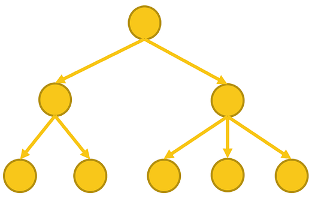

**Question 1** – The decision tree on the left has how many nodes?

**Question 2** – The decision tree on the left has how many branches?

**Question 3** – The decision tree on the left has how many leaves?

**Question 4** – Recursive binary splitting is a “greedy” approach because it [does / does not] look ahead, meaning it considers [splits at a particular step / all possible splits].

**Question 5** – Which approach is a better way to prune decision trees?

- Grow large trees and select a sub-tree that has the lowest test error rate
- Only make a tree larger (more nodes) if the split decreases the RSS by a specified amount

**Question 6** – The value of $\alpha$ in cost complexity pruning controls the trade-off between a tree’s complexity and its [testing error / fit to the training data].

**Question 7** – What value(s) should be used when evaluating the quality of a split? (select all that apply)

- accuracy
- Gini index
- entropy
- ROC

**Question 8** – A regression tree will typically outperform linear regression when there is a [linear / non-linear / additive / interactive] relationship between the predictors (features) and the response.

**Question 9** – Which of the following are disadvantages to using decision trees? (select all that apply)

- Trees are incredibly complex and difficult to explain to people
- Trees tend to have lower predictive accuracy
- Trees are sensitive to small changes in the data
- Trees are difficult to tune

**Question 10** – Bagging reduces the error of a decision tree by using bootstrapping, which resamples [with / without] replacement from the original training dataset to create a new training dataset.

**Question 11** – Using a large value of $B$ when bagging decision trees will result in overfitting.

- True
- False

**Question 12** – Suppose you are working with a dataset that contains 125 predictor variables and you are interested in using random forests to obtain your decision tree. When building a decision tree, how many of the predictor variables are considered at each split?

- 125
- 50
- 25
- a random sample of predictors from the 125

**Question 13** – A random forest decorrelates the decision trees because [strong predictors / moderate predictors / weak predictors] cannot dominate the structure of the trees, whereas, [boosting / bagging / BART] results in highly correlated trees

**Question 14** – Which method typically results in smaller trees?

- bagging
- random forests
- boosting
- BART

**Question 15** – In boosting, after an initial tree has been fit, a subsequent tree is fit to:

- the response
- the residuals
- the remaining predictor variables